# Investigating the Factors Affecting Appointment Attendance

## Introduction

The purpose of this document is to analyse the data based on sheduled medical appointments that were either attended or not by the patient. The data was obtained Kaggle and is based on 100k medical appointments in Brazil.

The analysis in this document attempts to answer the question "What factors affect appointment attendance?" based on the data set provided.

The field descriptions of dataset include:

1. 'PatientId' - Unique identifier for the patient
2. 'AppointmentID' - Unique identifier to mark appointment made
3. 'Gender' - Gender of the patient
4. ‘ScheduledDay’ - The day the patient set up their appointment.
5. 'AppointmentDay' - The day patient scheduled their appointment for
6. 'Age' - The age of the patient
7. ‘Neighborhood’ - The location of the hospital
8. ‘Scholarship’ - Whether or not the patient is enrolled in Brasilian welfare program Bolsa Família
9. 'Hipertension' - Whether or not the patient is hypertensive
10. 'Diabetes' - Whether or not the patient is diabetic
11. 'Alcoholism' - Whether or not the patient suffers from alcoholism
12. 'Handcap' - Whether or not the patient is handicapped
13. 'SMS Received' - Whether or not the patient receives an SMS about the appointment
14. 'No-show' - Whether or not the patient attends the appointment

## Data Wrangling

This section focuses on understanding the dataset. This section seeks to;

1. Know the size of the data set and the number of columns
2. The data types and unique values for each column
3. Identify opportunities for cleaning; checking for duplicate, null values and non-relevant values
4. To understand the characteristics of the data in each column

```python
import pandas as pd
import numpy as np
import matplotlib.pyplot as plt
import seaborn as sns
%matplotlib inline

df= pd.read_csv('noshowappointments-kagglev2-may-2016.csv')
df.head(1)
```

|  | PatientId | AppointmentID | Gender | ScheduledDay | AppointmentDay | Age | Neighbourhood | Scholarship | Hipertension | Diabetes | Alcoholism | Handcap | SMS_received | No-show |
| --- | --- | --- | --- | --- | --- | --- | --- | --- | --- | --- | --- | --- | --- | --- |
| 0 | 2.987250e+13 | 5642903 | F | 2016-04-29T18:38:08Z | 2016-04-29T00:00:00Z | 62 | JARDIM DA PENHA | 0 | 1 | 0 | 0 | 0 | 0 | No |

```python
df.shape
```

```
(110527, 14)
```

```python
df.dtypes
```

```
PatientId         float64
AppointmentID       int64
Gender             object
ScheduledDay       object
AppointmentDay     object
Age                 int64
Neighbourhood      object
Scholarship         int64
Hipertension        int64
Diabetes            int64
Alcoholism          int64
Handcap             int64
SMS_received        int64
No-show            object
dtype: object
```

```python
df.nunique()
```

```
PatientId          62299
AppointmentID     110527
Gender                 2
ScheduledDay      103549
AppointmentDay        27
Age                  104
Neighbourhood         81
Scholarship            2
Hipertension           2
Diabetes               2
Alcoholism             2
Handcap                5
SMS_received           2
No-show                2
dtype: int64
```

```python
sum(df.duplicated())
```

```
0
```

```python
df.isnull().sum()
```

```
PatientId         0
AppointmentID     0
Gender            0
ScheduledDay      0
AppointmentDay    0
Age               0
Neighbourhood     0
Scholarship       0
Hipertension      0
Diabetes          0
Alcoholism        0
Handcap           0
SMS_received      0
No-show           0
dtype: int64
```

```python
df['Gender'].unique()
```

```
array(['F', 'M'], dtype=object)
```

```python
type(df['Gender'][0])
```

```
str
```

```python
#Just getting a sense of the unique values in each column
labels = ['PatientId','AppointmentID', 'Gender', 'ScheduledDay', 'AppointmentDay', 'Age','Neighbourhood',
          'Scholarship', 'Hipertension', 'Diabetes', 'Alcoholism', 'Handcap', 'SMS_received', 'No-show' ]
for  i in labels:
    print(i)
    print(df[i].unique()[:10])
```

```
PatientId
[2.98724998e+13 5.58997777e+14 4.26296230e+12 8.67951213e+11
 8.84118645e+12 9.59851332e+13 7.33688164e+14 3.44983339e+12
 5.63947299e+13 7.81245644e+13]
AppointmentID
[5642903 5642503 5642549 5642828 5642494 5626772 5630279 5630575 5638447
 5629123]
Gender
['F' 'M']
ScheduledDay
['2016-04-29T18:38:08Z' '2016-04-29T16:08:27Z' '2016-04-29T16:19:04Z'
 '2016-04-29T17:29:31Z' '2016-04-29T16:07:23Z' '2016-04-27T08:36:51Z'
 '2016-04-27T15:05:12Z' '2016-04-27T15:39:58Z' '2016-04-29T08:02:16Z'
 '2016-04-27T12:48:25Z']
AppointmentDay
['2016-04-29T00:00:00Z' '2016-05-03T00:00:00Z' '2016-05-10T00:00:00Z'
 '2016-05-17T00:00:00Z' '2016-05-24T00:00:00Z' '2016-05-31T00:00:00Z'
 '2016-05-02T00:00:00Z' '2016-05-30T00:00:00Z' '2016-05-16T00:00:00Z'
 '2016-05-04T00:00:00Z']
Age
[62 56  8 76 23 39 21 19 30 29]
Neighbourhood
['JARDIM DA PENHA' 'MATA DA PRAIA' 'PONTAL DE CAMBURI' 'REPÚBLICA'
 'GOIABEIRAS' 'ANDORINHAS' 'CONQUISTA' 'NOVA PALESTINA' 'DA PENHA'
 'TABUAZEIRO']
Scholarship
[0 1]
Hipertension
[1 0]
Diabetes
[0 1]
Alcoholism
[0 1]
Handcap
[0 1 2 3 4]
SMS_received
[0 1]
No-show
['No' 'Yes']
```

```python
df['Handcap'].value_counts()
```

```
0    108286
1      2042
2       183
3        13
4         3
Name: Handcap, dtype: int64
```

Handcap should only have 2 unique values, as it is stated as a True or False column in Kaggle. It is going to be dropped

```python
df['Age'].describe()
```

```
count    110527.000000
mean         37.088874
std          23.110205
min          -1.000000
25%          18.000000
50%          37.000000
75%          55.000000
max         115.000000
Name: Age, dtype: float64
```

Age has a -1 value which is impossible, hence will be dropped data with this value will be dropped

```python
df.describe()
```

|  | PatientId | AppointmentID | Age | Scholarship | Hipertension | Diabetes | Alcoholism | Handcap | SMS_received |
| --- | --- | --- | --- | --- | --- | --- | --- | --- | --- |
| count | 1.105270e+05 | 1.105270e+05 | 110527.000000 | 110527.000000 | 110527.000000 | 110527.000000 | 110527.000000 | 110527.000000 | 110527.000000 |
| mean | 1.474963e+14 | 5.675305e+06 | 37.088874 | 0.098266 | 0.197246 | 0.071865 | 0.030400 | 0.022248 | 0.321026 |
| std | 2.560949e+14 | 7.129575e+04 | 23.110205 | 0.297675 | 0.397921 | 0.258265 | 0.171686 | 0.161543 | 0.466873 |
| min | 3.921784e+04 | 5.030230e+06 | -1.000000 | 0.000000 | 0.000000 | 0.000000 | 0.000000 | 0.000000 | 0.000000 |
| 25% | 4.172614e+12 | 5.640286e+06 | 18.000000 | 0.000000 | 0.000000 | 0.000000 | 0.000000 | 0.000000 | 0.000000 |
| 50% | 3.173184e+13 | 5.680573e+06 | 37.000000 | 0.000000 | 0.000000 | 0.000000 | 0.000000 | 0.000000 | 0.000000 |
| 75% | 9.439172e+13 | 5.725524e+06 | 55.000000 | 0.000000 | 0.000000 | 0.000000 | 0.000000 | 0.000000 | 1.000000 |
| max | 9.999816e+14 | 5.790484e+06 | 115.000000 | 1.000000 | 1.000000 | 1.000000 | 1.000000 | 4.000000 | 1.000000 |

### Data Cleaning

This sub-section is concerned with cleaning aspects of the data identified when assessing the data. In this section, the following actions where carried out:

1. Renaming Columns and aplying lower case to all columns
2. Spliting the "appointmentday' and 'schedule day' into day and time columns. Also converting fields into datetime data type
3. Dropping unuseful columns and the problematic row in the 'age' column

```python
#Rename the column Hipertension to Hypertension and No-show to No_show
df.rename(columns ={'Hipertension': 'Hypertension', 'No-show':'No_show' }, inplace = True)
```

```python
#Converting all comlumns to lowercase
df.rename(columns= lambda x:x.strip().lower(), inplace =True)
```

```python
df.head(1)
```

|  | patientid | appointmentid | gender | scheduledday | appointmentday | age | neighbourhood | scholarship | hypertension | diabetes | alcoholism | handcap | sms_received | no_show |
| --- | --- | --- | --- | --- | --- | --- | --- | --- | --- | --- | --- | --- | --- | --- |
| 0 | 2.987250e+13 | 5642903 | F | 2016-04-29T18:38:08Z | 2016-04-29T00:00:00Z | 62 | JARDIM DA PENHA | 0 | 1 | 0 | 0 | 0 | 0 | No |

```python
#Splitting ScheduleDay and AppointmentDay into two two columns to contain day and time
#https://datascienceparichay.com/article/pandas-split-column-by-delimiter/#:~:text=Split%20column%20by%20delimiter%20into,True%20to%20the%20expand%20parameter.

df[['scheduleddate','scheduledtime']] = df['scheduledday'].str.split('T', expand = True)
df['scheduledtime'] = df['scheduledtime'].str.replace('Z','')
df.head(1)
```

|  | patientid | appointmentid | gender | scheduledday | appointmentday | age | neighbourhood | scholarship | hypertension | diabetes | alcoholism | handcap | sms_received | no_show | scheduleddate | scheduledtime |
| --- | --- | --- | --- | --- | --- | --- | --- | --- | --- | --- | --- | --- | --- | --- | --- | --- |
| 0 | 2.987250e+13 | 5642903 | F | 2016-04-29T18:38:08Z | 2016-04-29T00:00:00Z | 62 | JARDIM DA PENHA | 0 | 1 | 0 | 0 | 0 | 0 | No | 2016-04-29 | 18:38:08 |

```python
df[['appointmentdate','appointmenttime']] = df['appointmentday'].str.split('T', expand = True)
df['appointmenttime'] = df['appointmenttime'].str.replace('Z','')
df.head(1)
```

|  | patientid | appointmentid | gender | scheduledday | appointmentday | age | neighbourhood | scholarship | hypertension | diabetes | alcoholism | handcap | sms_received | no_show | scheduleddate | scheduledtime | appointmentdate | appointmenttime |
| --- | --- | --- | --- | --- | --- | --- | --- | --- | --- | --- | --- | --- | --- | --- | --- | --- | --- | --- |
| 0 | 2.987250e+13 | 5642903 | F | 2016-04-29T18:38:08Z | 2016-04-29T00:00:00Z | 62 | JARDIM DA PENHA | 0 | 1 | 0 | 0 | 0 | 0 | No | 2016-04-29 | 18:38:08 | 2016-04-29 | 00:00:00 |

```python
column = ['scheduledtime','scheduleddate','appointmentdate','appointmenttime']
for i in column:
    df[i]= pd.to_datetime(df[i])
```

```python
df.dtypes
```

```
patientid                 float64
appointmentid               int64
gender                     object
scheduledday               object
appointmentday             object
age                         int64
neighbourhood              object
scholarship                 int64
hypertension                int64
diabetes                    int64
alcoholism                  int64
handcap                     int64
sms_received                int64
no_show                    object
scheduleddate      datetime64[ns]
scheduledtime      datetime64[ns]
appointmentdate    datetime64[ns]
appointmenttime    datetime64[ns]
dtype: object
```

```python
type(df['scheduledtime'][0])
```

```
pandas._libs.tslibs.timestamps.Timestamp
```

```python
#Removing the row with age = -1
df.drop(df[df['age'] == -1].index, inplace = True)
```

```python
#Dropping scheduledday, appointmentday, handcap, appointmenttime, patientid

df =df.drop(['scheduledday', 'appointmentday', 'handcap', 'appointmenttime', 'patientid'], axis =1)
df.head(1)
```

|  | appointmentid | gender | age | neighbourhood | scholarship | hypertension | diabetes | alcoholism | sms_received | no_show | scheduleddate | scheduledtime | appointmentdate |
| --- | --- | --- | --- | --- | --- | --- | --- | --- | --- | --- | --- | --- | --- |
| 0 | 5642903 | F | 62 | JARDIM DA PENHA | 0 | 1 | 0 | 0 | 0 | No | 2016-04-29 | 2022-08-20 18:38:08 | 2016-04-29 |

```python
df.shape
```

```
(110526, 13)
```

```python
df.to_csv('clean_noshowappointsment.csv', index = False)
```

## Analysis Section

This section is concerned with answering the questions, "What factors affect appointment attendance?" A general analysis was carried out on the data set and based on the main question, 4 sub- questions were explored:

1. Does the gender of the patients affect no-show appointments?
2. Does the existence of disease(s) of patient affect no-show appointments?
3. Does receiving SMS affect no-show appointments?
4. Does having a scholarship affect no_show appointments?

### General Analysis

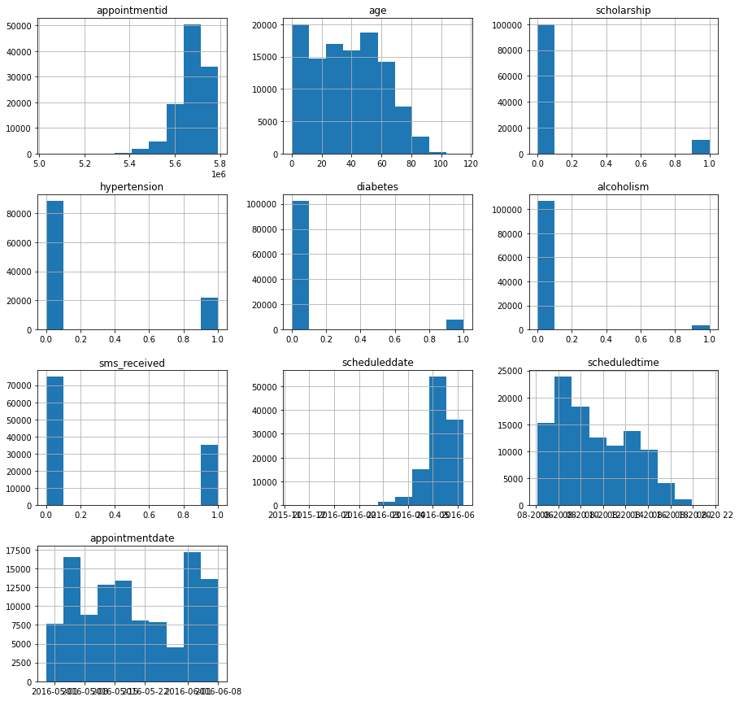

```python
df.hist(figsize=(15,15));
```

```python
df['no_show'].value_counts()
```

```
No     88207
Yes    22319
Name: no_show, dtype: int64
```

```python
#number of no-show and attended appointments
no_show = df.query('no_show == "Yes"').appointmentid.nunique()
attend = df.query('no_show == "No"').appointmentid.nunique()
no_show, attend
```

```
(22319, 88207)
```

```python
#total number of appointments
tot_app = df.appointmentid.nunique()
tot_app
```

```
110526
```

```python
#proportion of no show and attended appointments
no_show_prop = no_show/tot_app
attend_prop = attend/tot_app

no_show_prop, attend_prop
```

```
(0.20193438647919945, 0.7980656135208005)
```

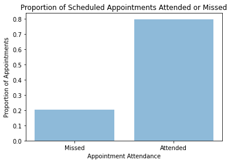

```python
plt.bar(['Missed', 'Attended'], [no_show_prop, attend_prop], alpha =0.5)
plt.title("Proportion of Scheduled Appointments Attended or Missed")
plt.xlabel("Appointment Attendance")
plt.ylabel("Proportion of Appointments");
```

This means that roughly 20% of scheduled appointments are being missed.

```python
no_show_mask =df.no_show == 'Yes'
attend_mask =df.no_show == 'No'
```

### Does the gender of the patients affect no-show appointments?

```python
#Exploring the effect of gender, finding the proportion of male and female
tot_gender = df.groupby('gender').appointmentid.count()
tot_gender
```

```
gender
F    71839
M    38687
Name: appointmentid, dtype: int64
```

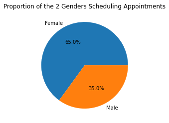

```python
plt.pie(tot_gender, labels= ['Female', 'Male'], autopct ='%1.1f%%')
plt.title('Proportion of the 2 Genders Scheduling Appointments')
#plt.legend()
plt.show();
```

```python
#Proportion of Male and Female who attend their appointments
no_show_gender = df.gender[no_show_mask].value_counts()
no_show_gender
```

```
F    14594
M     7725
Name: gender, dtype: int64
```

```python
prop_gender = no_show_gender/tot_gender
prop_gender
```

```
F    0.203149
M    0.199679
dtype: float64
```

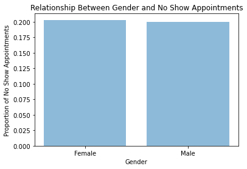

```python
plt.bar(['Female', 'Male'], prop_gender, alpha =0.5)
plt.title("Relationship Between Gender and No Show Appointments")
plt.xlabel("Gender")
plt.ylabel("Proportion of No Show Appointments");
```

Based on this the analysis, the gender has more or less the no effect on the no_show appointment. Both Male and Female miss their appointment roughly 20% of time which is the same as the general trend of No Show Appointments

### Does the existence of disease(s) of patient affect no-show appointments?

```python
#Exploring the effect of disease of the patient, finding the proportion of the various diseases by appointment
list_disease = ['diabetes','hypertension', 'alcoholism']
ns_d = []
tot_d = []
prop_d = []

for i in list_disease:
    ns = df[i][no_show_mask].value_counts()[1]
    ns_d.append(ns)
    tot_ = df[i].value_counts()[1]
    tot_d.append(tot_)
    prop_ = ns/tot_
    prop_d.append(prop_)

print(ns_d)
print(tot_d)
print(prop_d)
```

```
[1430, 3772, 677]
[7943, 21801, 3360]
[0.18003273322422259, 0.17301958625751113, 0.20148809523809524]
```

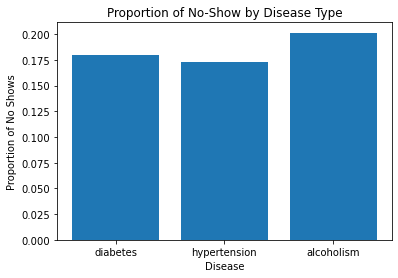

```python
plt.bar(list_disease, prop_d)
plt.title("Proportion of No-Show by Disease Type")
plt.xlabel("Disease")
plt.ylabel("Proportion of No Shows");
```

```python
#Check to see if patients have multiple ailments (total appointments- number of patiences without diabetes, hypertension and alcholism == total cases of disease group)
df.appointmentid.count() - df.query('diabetes == False & hypertension == False & alcoholism == False').appointmentid.count() == sum(tot_d)
```

```
False
```

The code above shows that a patient may have multiple ailments/disease. Going to explore the different combinations of disease within the data set

```python
#All Diseases
df_alld = df.query('diabetes == True & hypertension == True & alcoholism == True')
tot_alld = df_alld.appointmentid.count()
ns_alld = df_alld.appointmentid[no_show_mask].count()
prop_alld = ns_alld/tot_alld
prop_alld, tot_alld
```

```
(0.1796875, 256)
```

```python
#Diabetes & Hypertension
df_dh = df.query('diabetes == True & hypertension == True & alcoholism == False')
tot_dh = df_dh.appointmentid.count()
ns_dh = df_dh.appointmentid[no_show_mask].count()
prop_dh = ns_dh/tot_dh
prop_dh, tot_dh
```

```
(0.17576243980738362, 6230)
```

```python
#Diabetes & Alcoholism
df_da = df.query('diabetes == True & hypertension == False & alcoholism == True')
tot_da = df_da.appointmentid.count()
ns_da = df_da.appointmentid[no_show_mask].count()
prop_da = ns_da/tot_da
prop_da, tot_da
```

```
(0.17105263157894737, 76)
```

```python
#Hypertension & Alcoholism
df_ha = df.query('diabetes == False & hypertension == True & alcoholism == True')
tot_ha = df_ha.appointmentid.count()
ns_ha = df_ha.appointmentid[no_show_mask].count()
prop_ha = ns_da/tot_ha
prop_ha, tot_ha
```

```
(0.012138188608776844, 1071)
```

```python
#Diabetes alone
df_d = df.query('diabetes == True & hypertension == False & alcoholism == False')
tot_d = df_d.appointmentid.count()
ns_d = df_d.appointmentid[no_show_mask].count()
prop_d = ns_d/tot_d
prop_d, tot_d
```

```
(0.1998551774076756, 1381)
```

```python
#Hypertension alone
df_h = df.query('diabetes == False & hypertension == True & alcoholism == False')
tot_h = df_h.appointmentid.count()
ns_h = df_h.appointmentid[no_show_mask].count()
prop_h = ns_h/tot_h
prop_h, tot_h
```

```
(0.17080876158382477, 14244)
```

```python
#alcoholism alone
df_a = df.query('diabetes == False & hypertension == False & alcoholism == True')
tot_a = df_a.appointmentid.count()
ns_a = df_a.appointmentid[no_show_mask].count()
prop_a = ns_a/tot_a
prop_a, tot_a
```

```
(0.21461420541645376, 1957)
```

```python
#no disease
df_n = df.query('diabetes == False & hypertension == False & alcoholism == False')
tot_n = df_n.appointmentid.count()
ns_n = df_n.no_show.value_counts()['Yes']
prop_n = ns_n/tot_n
prop_n, tot_n
```

```
(0.2090937862643739, 85311)
```

```python
list_prop_d = [prop_n, prop_a, prop_h, prop_d, prop_ha, prop_da, prop_dh, prop_alld]
list_tot_d = [tot_n, tot_a, tot_h, tot_d, tot_ha, tot_da, tot_dh, tot_alld]
list_name_d =['No Disease', 'Alcoholism', 'Hypertension', 'Diabetes', 'Hypertension & Alcoholism', 'Diabetes & Alcoholism', 'Diabetes & Hypertension', 'All disease']
```

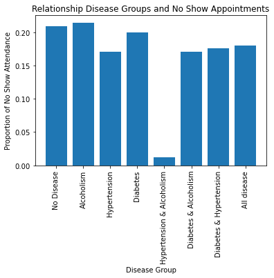

```python
plt.bar(list_name_d, list_prop_d)
plt.title("Relationship Disease Groups and No Show Appointments")
plt.xlabel("Disease Group")
plt.ylabel("Proportion of No Show Attendance")
plt.xticks(rotation=90);
```

### Does receiving SMS affect no-show appointments?

```python
#Exploring the effect of receiving SMS, finding the proportion of SMS received
tot_sms = df.groupby('sms_received').appointmentid.count()
tot_sms
```

```
sms_received
0    75044
1    35482
Name: appointmentid, dtype: int64
```

```python
#defining a function to aid with the calculation of proportions for each grouping
def proportion(data_frame, ind_column, dep_column, ind):
    """The purpose of this function is to calculate the proportions of unique values of the independent variable/column
    while filtering based on the dependent variable/column """
    tot1 = data_frame.groupby(ind_column)[dep_column].value_counts()
    tot2 = data_frame.groupby(ind_column)[dep_column].count()
    tot3 = tot1[ind]
    prop3 = tot3/tot2[ind]
    return(prop3)
```

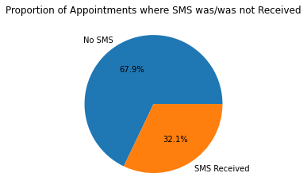

```python
plt.pie(tot_sms, labels= ['No SMS', 'SMS Received'], autopct ='%1.1f%%')
plt.title('Proportion of Appointments where SMS was/was not Received')
#plt.legend()
plt.show();
```

```python
#counting the number of appointments attended or missed based on the sms_received grouping
no_sms = df.groupby('sms_received')['no_show'].value_counts()[0]
sms_r = df.groupby('sms_received')['no_show'].value_counts()[1]
labels_sms = ['Attended Appointment', 'No Show']
```

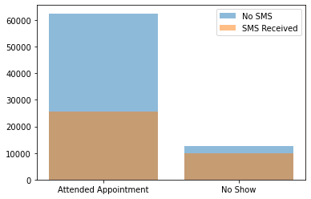

```python
plt.bar(labels_sms, no_sms, alpha =0.5, label ='No SMS' )
plt.bar(labels_sms, sms_r, alpha =0.5, label = 'SMS Received')
plt.legend();
```

```python
#proportion of no-show based on sms received or not
prop_no_sms = proportion(df,'sms_received', 'no_show', 0)['Yes'] #no sms
prop_sms_r = proportion(df,'sms_received', 'no_show', 1)['Yes']   #sms received
prop_no_sms, prop_sms_r
```

```
(0.16703533926762965, 0.27574544839637)
```

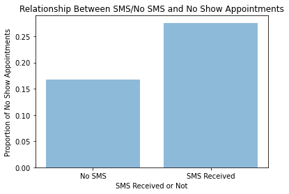

```python
plt.bar(['No SMS', 'SMS Received'], [prop_no_sms, prop_sms_r], alpha =0.5)
plt.title("Relationship Between SMS/No SMS and No Show Appointments")
plt.xlabel("SMS Received or Not")
plt.ylabel("Proportion of No Show Appointments");
```

Data shows that the proportion of no show increased when SMS was received by the Patient

```python
#Exploring the effect of having a scholarship, finding the proportion of scholarship appointments
tot_sch = df.groupby('scholarship').appointmentid.count()
```

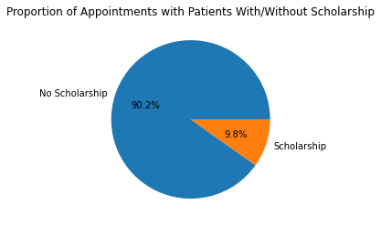

```python
plt.pie(tot_sch, labels= ['No Scholarship', 'Scholarship'], autopct ='%1.1f%%')
plt.title('Proportion of Appointments with Patients With/Without Scholarship')
#plt.legend()
plt.show();
```

```python
#proportion of no-show based on Scholarship
prop_no_sch = proportion(df,'scholarship', 'no_show', 0)['Yes'] #no scholarship
prop_sch = proportion(df,'scholarship', 'no_show', 1)['Yes']   #scholarship
prop_no_sch, prop_sch
```

```
(0.19807354638037425, 0.2373630420771568)
```

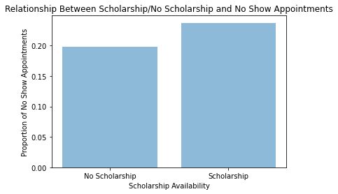

```python
plt.bar(['No Scholarship', 'Scholarship'], [prop_no_sch, prop_sch], alpha =0.5)
plt.title("Relationship Between Scholarship/No Scholarship and No Show Appointments")
plt.xlabel("Scholarship Availability")
plt.ylabel("Proportion of No Show Appointments");
```

Bar chart shows that the people without scholarship tended to attend their scheduled appointments compared with those who had their healthcare sponsored or had scholarship

## Conclusion

### Results

The main purpose of this analysis is to answer the question "What factors affect appointment attendance?", 4 variables were investigated;

1. Gender
2. Existence of Disease
3. SMS received
4. Scholarship

Based on the analysis, it was deduced that the gender of patients had no effect on no show as it followed the general no show trend.

The data also, showed an unexpected trend for no show appointments when SMS is received. The appointments where SMS was received had a worse attendance than those who had not receive SMS. The number people that receive SMS are around 30% and may be attributed to them opting to receive an SMS possibly because they maybe forgetful. So going along that line, their forgetfulness may have contributed to missing their appointments

Finally scholarship, people with scholarship show a worse attendance than those who pay for medical services. This may be due to the fact, the people who pay for medical services will likely not want to pay penalties for missing their appointments, hence lower no show appointments when compared with those who are sponsored, who will likely not pay any penalties for missing their appointments.

### Limitations

The major limitation of the data is that variables provided cannot adequately predict why patients will not show up for appointments and more information is required to make better conclusions. For example, with the disease groups, the purpose of the appointment may inform a better judgement as to why the patients did not attend their appointments as patients may schedule appointments for other purposes outside their ailment(s). Another example is the SMS received, the dataset does provide data that could be further explored to know why turnout was worst despite receiving SMS.